# Analysis on species-specific pathways

Xiaoxi Dong

# Number of pathway per species distribution

This analysis used pre-defined pathway-specific completeness cutoffs.

Number of pathway per species distribution. Violin plot’s width represent density.

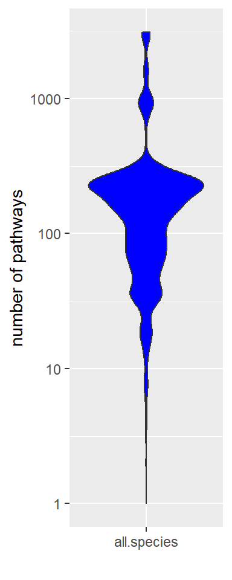

## Top 20 species with largest number of pathways

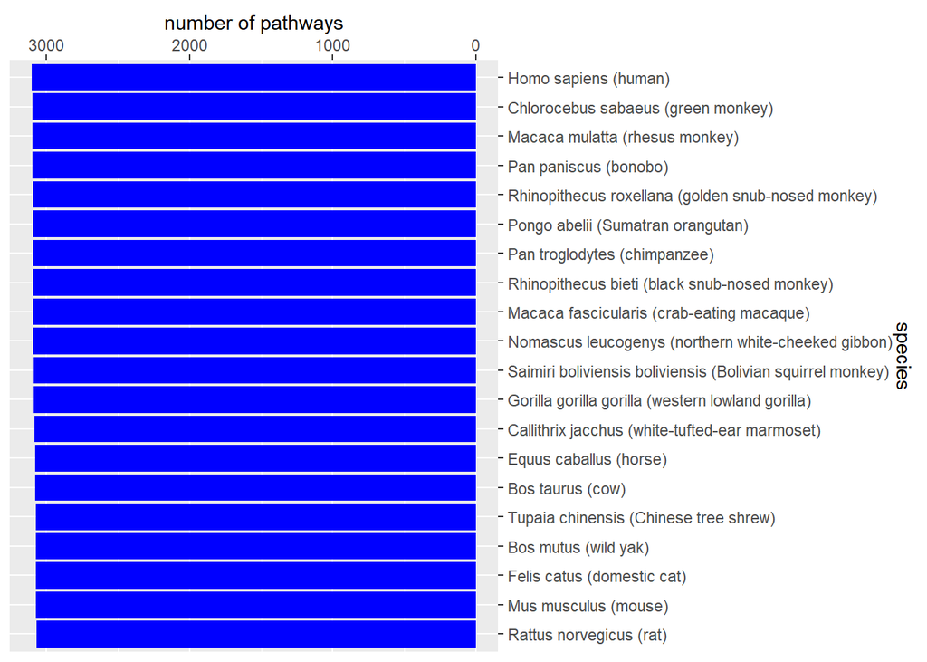

# Number of species per pathway distribution. Violin plot’s width represent density.

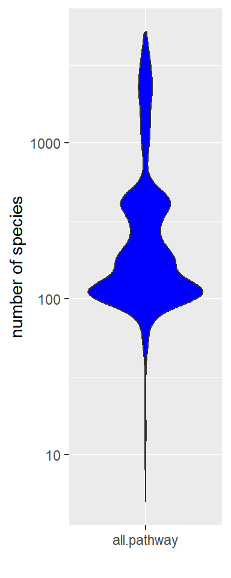

## Check some pathways distributed most widely or narrowly

```
##                                                         pathway.name count
## 6                                     mineralocorticoid biosynthesis     5
## 4                                               menthol biosynthesis     8
## 8                                          Ifosfamide Action Pathway    11
## 7                                                   CYP2E1 reactions    13
## 11                                  Rosiglitazone Metabolism Pathway    14
## 10                                       Tramadol Metabolism Pathway    15
## 5                                inosine-5'-phosphate biosynthesis I  4761
## 1  superpathway of purine nucleotides <i>de novo</i> biosynthesis II  4942
## 9                              Adefovir Dipivoxil Metabolism Pathway  5007
## 2                                pentose phosphate pathway (partial)  5119
## 3                Entner-Doudoroff pathway III (semi-phosphorylative)  5133
```

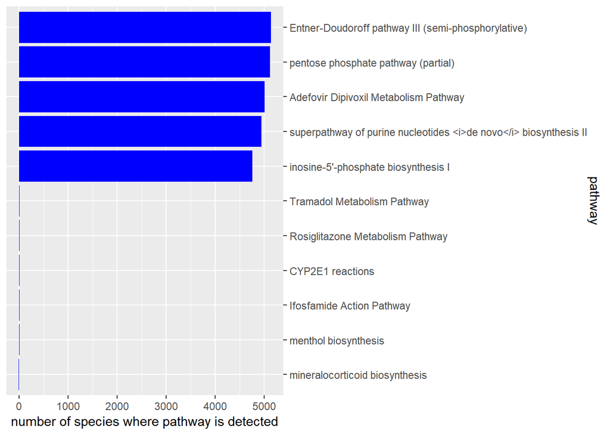

## The species where the most narrowly distributed pathways are found:

```
## $`CYP2E1 reactions`
##  [1] "Homo sapiens (human)"
##  [2] "Nomascus leucogenys (northern white-cheeked gibbon)"
##  [3] "Pongo abelii (Sumatran orangutan)"
##  [4] "Macaca mulatta (rhesus monkey)"
##  [5] "Callithrix jacchus (white-tufted-ear marmoset)"
##  [6] "Chlorocebus sabaeus (green monkey)"
##  [7] "Gorilla gorilla gorilla (western lowland gorilla)"
##  [8] "Rhinopithecus roxellana (golden snub-nosed monkey)"
##  [9] "Pan paniscus (bonobo)"
## [10] "Pan troglodytes (chimpanzee)"
## [11] "Macaca fascicularis (crab-eating macaque)"
## [12] "Saimiri boliviensis boliviensis (Bolivian squirrel monkey)"
## [13] "Rhinopithecus bieti (black snub-nosed monkey)"
##
```

[output cut: 45 more lines]

Check what happened to the most narrowly distributed pathway “mineralocorticoid biosynthesis: MetaCyc PWY66-382”

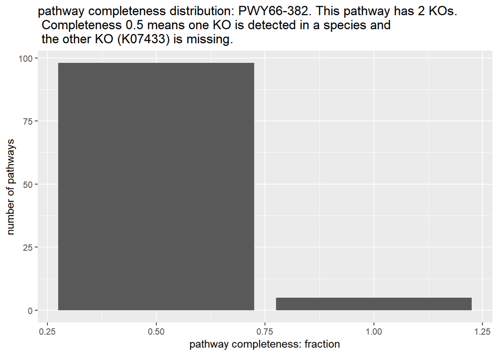

It looks like this pathway has only two KOs. One of the KO (K07433) is missing in a lot of species.

```r
read.table("http://rest.kegg.jp/link/genes/K07433")
```

```
##          V1            V2
## 1 ko:K07433      hsa:1585
## 2 ko:K07433 pps:100971238
## 3 ko:K07433    mcc:695914
## 4 ko:K07433 mcf:102137301
## 5 ko:K07433    mmu:110115
## 6 ko:K07433    rno:500892
```

K07433 was only detected in 6 species, according to KEGG ortholog definition. This is why the pathway is predicted to exist in only 5 species( the other KO:K00513 is missing in pps, so it is 5=6-1)

KEGG doesn’t have this pathway. In MetaCyc, it is annotated to exist in Mammalia: https://biocyc.org/META/NEW-IMAGE?type=PATHWAY&object=PWY66-382 In reactome, this pathway is annotated in many other species, as distant as Saccharomyces cerevisiae https://reactome.org/content/detail/R-HSA-193993 It doesn’t make much sense that S.cerevisiae has this pathway because “Mineralocorticoids are a class of corticosteroids, which in turn are a class of steroid hormones. Mineralocorticoids are produced in the adrenal cortex and influence salt and water balances.”

So species-specific pathway prediction is affected by ortholog prediction: KEGG’s BlastKOALA only uses sequence similarity but reactome’s Compara fits similarity network of proteins to species tree. It looks like MetaCyc’s species distribution (Mammalia) makes more sense.

To solve this issue, maybe I can try different ortholog annotation databases/algorithms

# Distribution of F statistics. Violin plot’s width represent density.

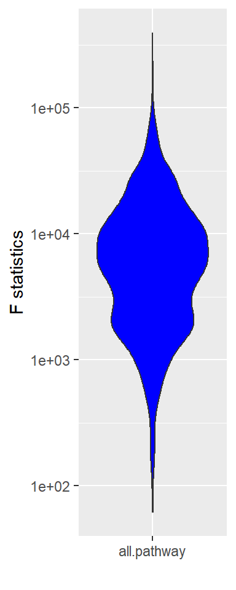